# presentación-informe-final

## **Actitudes Pro-Mercado y Contexto Económico: Influencia en la Confianza Institucional en América Latina**

**Yerkho Nuñez, Dorian Ñanco y Morgan Salazar**

**Análisis de datos multinivel - 2025**

27 de Junio de 2025

## Introducción

**Problema de estudio:**

La confianza en las instituciones es un pilar fundamental para la gobernabilidad y la cohesión social Sin embargo, la región ha experimentado históricamente bajos niveles de confianza, a menudo exacerbados por factores como la desigualdad estructural y los procesos de reforma neoliberal (CEPAL, 2021; Portes & Hoffman, 2003).

En este contexto, surge la pregunta sobre cómo las actitudes individuales hacia el mercado y el modelo económico predominante se relacionan con la percepción de legitimidad de las instituciones públicas (Fourcade-Gourinchas & Babb, 2002).

¿De que manera las actitudes pro-mercado individuales y el contexto economico del pais afectan la confianza en instituciones gubernamentales en America Latina?

## Hipótesis

### Nivel 1 (Individual):

**H1:** A mayor *Confianza en Sector Privado (CSP)* ➔ Menor Confianza Institucional (CIG).

**H2:** A mayor *Aceptación de la Desigualdad (AD)* ➔ Menor Confianza Institucional (CIG).

### Nivel 2 (Contextual):

**H4:** Un mayor *Índice de GINI* ➔ Menor Confianza Institucional (CIG).

## Interacción entre Niveles:

**H5:** El efecto de AD sobre CIG será más negativo en países con mayor GINI.

**H6:** El efecto de CSP sobre CIG será menos negativo en países con mayor Gasto Social.

## Metodología: Datos y Variables

- **Fuente de Datos:** Encuesta Latinobarómetro 2023 y DatosMacro.
- **Muestra:** 13,361 individuos en 15 países.
- **Variable Dependiente (VD):** Índice de Confianza Institucional [CIG].
- **Variables Independientes (Nivel 1):** Índice de Confianza en Sector Privado [CSP], Índice de Aceptación de la Desigualdad [AD], Sexo, Edad.
- **Variables Contextuales (Nivel 2):** Gasto Social (% del PIB)[GS], Índice de Gini[GINI], PIB per cápita(En miles de dolares)[PPC].

## Metodología: Modelos Estadísticos

## Modelo 1: Variables Individuales.

$$\text{CIG}_{ij} \;=\; \gamma_{00}
+ \gamma_{10}\,(\text{CSP}_{ij})
+ \gamma_{20}\,(\text{AD}_{ij})
+ \gamma_{30}\,(\text{Sexo}_{ij})
+ \\
+ \gamma_{40}\,(\text{Edad}_{ij})
+ u_{0\text{j}}
+ e_{ij}$$

## Modelo 2: Variables Contextuales

$$\text{CIG}_{ij} \;=\; \gamma_{00}
+ \gamma_{01}\,(\text{GINI}_{j})
+ \gamma_{02}\,(\text{GS}_{j})
+ \gamma_{03}\,(\text{PPC}_{j})
+ u_{0\text{j}}
+ e_{ij}$$

## Modelo 3: Multinivel

$$\text{CIG}_{ij} \;=\; \gamma_{00}
+ \gamma_{10}\,(\text{CSP}_{ij})
+ \gamma_{20}\,(\text{AD}_{ij})
+ \gamma_{30}\,(\text{Sexo}_{ij})
+ \\
+ \gamma_{40}\,(\text{Edad}_{ij})
+ \gamma_{01}\,(\text{GINI}_{j})
+ \gamma_{02}\,(\text{GS}_{j})
+ \gamma_{03}\,(\text{PPC}_{j})
+ u_{0\text{j}}
+ e_{ij}$$

## Modelo 4: Pendiente Aleatoria

$$\text{CIG}_{ij} \;=\; \gamma_{00}
+ \gamma_{10}\,(\text{CSP}_{ij})
+ \gamma_{20}\,(\text{AD}_{ij})
+ \gamma_{30}\,(\text{Sexo}_{ij})
+ \\
+ \gamma_{40}\,(\text{Edad}_{ij})
+ \gamma_{01}\,(\text{GINI}_{j})
+ \gamma_{02}\,(\text{GS}_{j})
+ \gamma_{03}\,(\text{PPC}_{j})
+ u_{0j}
+ \\
+ u_{1j}(\text{CSP}_{ij})
+ u_{2j}(\text{AD}_{ij})
+ e_{ij}$$

## Modelo 5: Interacción entre Niveles

$$\text{CIG}_{ij} \;=\; \gamma_{00}
+ \gamma_{10}\,(\text{CSP}_{ij})
+ \gamma_{20}\,(\text{AD}_{ij})
+ \gamma_{30}\,(\text{Sexo}_{ij})
+ \\
+ \gamma_{40}\,(\text{Edad}_{ij})
+ \gamma_{01}\,(\text{GINI}_{j})
+ \gamma_{02}\,(\text{GS}_{j})
+\\
+ \gamma_{03}\,(\text{PPC}_{j})
+ \gamma_{11}\,(\text{CSP}_{ij} \cdot \text{GS}_{j})
+ \gamma_{21}\,(\text{AD}_{ij} \cdot \text{GINI}_{j})
+ u_{0j}
+ \\
+ u_{1j}(\text{CSP}_{ij})
+ u_{2j}(\text{AD}_{ij})
+ e_{ij}$$

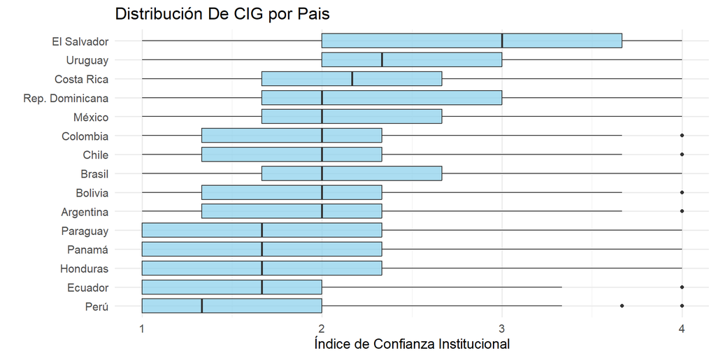

## Tabla Desriptivos N1

Tabla 1: Variables Nivel 1

|  | var | n | mean | sd | range |
| --- | --- | --- | --- | --- | --- |
| 2 | CIG | 13361 | 2.02 | 0.79 | 3 (1-4) |
| 3 | CSP | 13361 | 2.45 | 0.71 | 3 (1-4) |
| 1 | AD | 13361 | 0.00 | 0.78 | 3.51 (-1.22-2.29) |
| 5 | NE | 13361 | 4.54 | 1.68 | 7 (0-7) |
| 6 | Sexo | 13361 | 1.49 | 0.50 | 1 (1-2) |
| 4 | Edad | 13361 | 40.11 | 15.95 | 76 (16-92) |

## Tabla Descriptivos N2

Tabla 2: Variables Nivel 2

|  | var | n | mean | sd | range |
| --- | --- | --- | --- | --- | --- |
| 3 | PPC | 15 | 10.92 | 6.02 | 19.57 (3.23-22.8) |
| 1 | GINI | 15 | 44.33 | 5.02 | 17.8 (37-54.8) |
| 2 | GS | 15 | 29.50 | 7.99 | 26.8 (18.51-45.31) |

## Relación Variables Nivel 2 y CIG

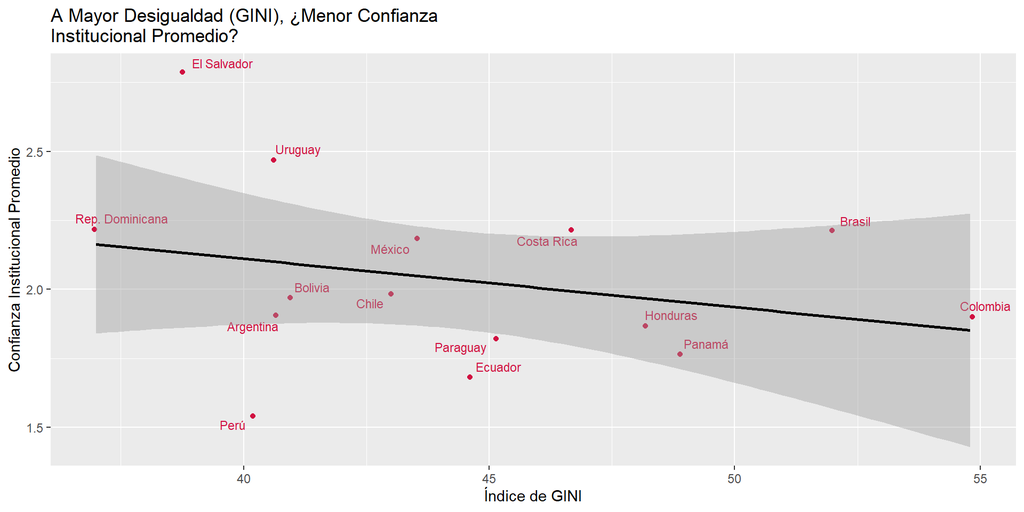

Relación entre el Índice de GINI y la Confianza Institucional Promedio por País

## Relación Variables Nivel 2 y CIG

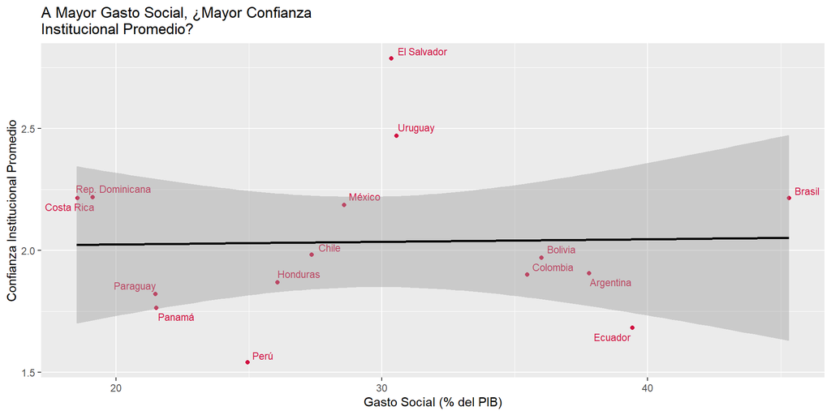

Relación entre el Gasto Social y la Confianza Institucional Promedio por País

## Modelos

Secuencia de Modelos Multinivel para la Confianza Institucional

|  | Modelo Nulo |  | Nivel 1 |  | Nivel 2 |  |
| --- | --- | --- | --- | --- | --- | --- |
| Predictors | Estimates | std. Error | Estimates | std. Error | Estimates | std. Error |
| (Intercept) | 2.03 *** | 0.08 | 2.03 *** | 0.08 | 2.03 *** | 0.07 |
| ind_conf_priv_c |  |  | 0.43 *** | 0.01 |  |  |
| ind_desig_c |  |  | 0.21 *** | 0.01 |  |  |
| sexo |  |  | 0.00 | 0.01 |  |  |
| edad_c |  |  | 0.00 | 0.00 |  |  |
| gasto_social_c |  |  |  |  | 0.01 | 0.01 |
| gini_c |  |  |  |  | -0.02 | 0.02 |
| pib_per_capita_c |  |  |  |  | 0.01 | 0.01 |
| Random Effects |  |  |  |  |  |  |
| σ<sup>2</sup> | 0.53 |  | 0.40 |  | 0.53 |  |
| τ<sub>00</sub> | 0.10 <sub>pais</sub> |  | 0.10 <sub>pais</sub> |  | 0.08 <sub>pais</sub> |  |
| ICC | 0.15 |  | 0.19 |  | 0.13 |  |
| N | 15 <sub>pais</sub> |  | 15 <sub>pais</sub> |  | 15 <sub>pais</sub> |  |
| Observations | 13361 |  | 13361 |  | 13361 |  |
| Marginal R<sup>2</sup> / Conditional R<sup>2</sup> | 0.000 / 0.151 |  | 0.214 / 0.365 |  | 0.022 / 0.151 |  |
| * p<0.05 ** p<0.01 *** p<0.001 |  |  |  |  |  |  |

## Modelos

Secuencia de Modelos Multinivel para la Confianza Institucional

|  | Combinado |  | Pendiente Aleatoria |  | Interacción |  |
| --- | --- | --- | --- | --- | --- | --- |
| Predictors | Estimates | std. Error | Estimates | std. Error | Estimates | std. Error |
| Intercepto | 2.03 *** | 0.08 | 2.03 *** | 0.08 | 2.03 *** | 0.08 |
| CSP | 0.43 *** | 0.01 | 0.43 *** | 0.02 | 0.43 *** | 0.02 |
| AD | 0.21 *** | 0.01 | 0.21 *** | 0.02 | 0.21 *** | 0.02 |
| Sexo (Mujer) | 0.00 | 0.01 | 0.00 | 0.01 | 0.00 | 0.01 |
| Edad | 0.00 | 0.00 | 0.00 | 0.00 | 0.00 | 0.00 |
| GS | 0.01 | 0.01 | 0.01 * | 0.01 | 0.01 | 0.01 |
| GINI | -0.02 | 0.02 | -0.01 | 0.01 | -0.02 * | 0.01 |
| PPC | 0.01 | 0.01 | 0.02 * | 0.01 | 0.02 * | 0.01 |
| CSP x GS |  |  |  |  | -0.00 | 0.00 |
| AD x GINI |  |  |  |  | -0.01 * | 0.00 |
| Random Effects |  |  |  |  |  |  |
| σ<sup>2</sup> | 0.40 |  | 0.39 |  | 0.39 |  |
| τ<sub>00</sub> | 0.08 <sub>pais</sub> |  | 0.09 <sub>pais</sub> |  | 0.08 <sub>pais</sub> |  |
| τ<sub>11</sub> |  |  | 0.01 <sub>pais.ind_conf_priv_c</sub> |  | 0.01 <sub>pais.ind_conf_priv_c</sub> |  |
|  |  |  | 0.01 <sub>pais.ind_desig_c</sub> |  | 0.00 <sub>pais.ind_desig_c</sub> |  |
| ρ<sub>01</sub> |  |  | 0.86 |  | 0.86 |  |
|  |  |  | 0.38 |  | 0.34 |  |
| ICC | 0.17 |  | 0.19 |  | 0.18 |  |
| N | 15 <sub>pais</sub> |  | 15 <sub>pais</sub> |  | 15 <sub>pais</sub> |  |
| Observations | 13361 |  | 13361 |  | 13361 |  |
| Marginal R<sup>2</sup> / Conditional R<sup>2</sup> | 0.236 / 0.365 |  | 0.236 / 0.380 |  | 0.240 / 0.378 |  |
| * p<0.05 ** p<0.01 *** p<0.001 |  |  |  |  |  |  |

## Analisis de influencias

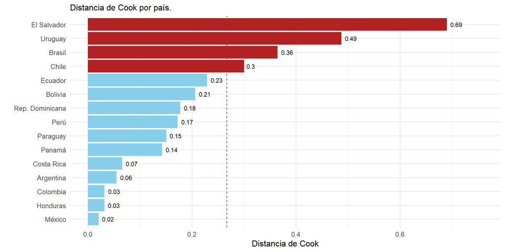

## Referencias

CEPAL (Comisión Económica para América Latina y el Caribe). (2021). *Panorama Social de América Latina 2020*.

Harvey, D. (2007). *Breve historia del neoliberalismo*.

Kahan, D. M. (2001). Trust, Collective Action, and Law. *Boston University Law Review, 81*(1).

Corporación Latinobarómetro. (2023). *Latinobarómetro Estudio 2023: Libro de Códigos*.

North, D. C. (1993). *Instituciones, cambio institucional y desempeño económico*.

Portes, A., & Hoffman, K. (2003). Latin American Class Structures. *Latin American Research Review, 38*(1).

Smulovitz, C., & Peruzzotti, E. (2000). Societal Accountability in Latin America. *Journal of Democracy, 11*(4).